# Bellabeat User Behavior Analysis

Ken Tseng

2023-07-26

```r
knitr::opts_chunk$set(echo = TRUE)
options(repos = c(CRAN = "https://cloud.r-project.org"))
library(tidyverse)
library(lubridate)
library(ggplot2)
```

## Introduction

Here we analyze user behavior data from our fitness app. The goal is to understand trends and habits among our users, and use these insights to attract and retain more users.

## Data Overview

```r
# Read the daily activity data
dailyactivity <- read.csv("/Users/kentseng/Desktop/Google Certificate/Bellabeat_ Project_Fitabase Data /Bellabeat_User_Behavior_Analysis/csv_files/dailyActivity_merged.csv")

# Read the daily calories data
dailyclalories <- read.csv("//Users/kentseng/Desktop/Google Certificate/Bellabeat_ Project_Fitabase Data /Bellabeat_User_Behavior_Analysis/csv_files/dailyCalories_merged.csv")

# Read the daily steps data
dailysteps <- read.csv("/Users/kentseng/Desktop/Google Certificate/Bellabeat_ Project_Fitabase Data /Bellabeat_User_Behavior_Analysis/csv_files/dailySteps_merged.csv")

# Read the heart_rate data
heartrate <- read.csv("/Users/kentseng/Desktop/Google Certificate/Bellabeat_ Project_Fitabase Data /Bellabeat_User_Behavior_Analysis/csv_files/heartrate_seconds_merged.csv")

# Read the sleep day data
sleepday <- read.csv("/Users/kentseng/Desktop/Google Certificate/Bellabeat_ Project_Fitabase Data /Bellabeat_User_Behavior_Analysis/csv_files/update_sleepDay_merged.csv")

# Read the weight log info data
weightloginfo <- read.csv("/Users/kentseng/Desktop/Google Certificate/Bellabeat_ Project_Fitabase Data /Bellabeat_User_Behavior_Analysis/csv_files/update_weightLogInfo_merged.csv")
```

## Analysis

Distribution of Activity Intensity

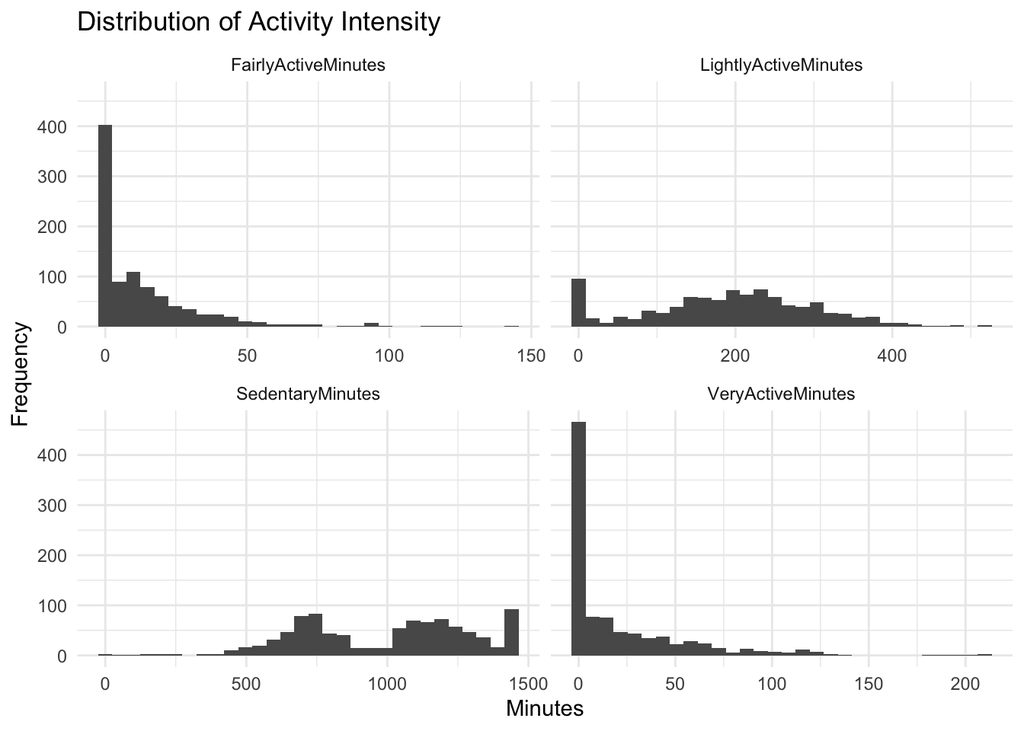

```r
#Activity Intensity Distribution
dailyactivity %>%
  gather(key = "ActivityIntensity", value = "Minutes", VeryActiveMinutes, FairlyActiveMinutes, LightlyActiveMinutes, SedentaryMinutes) %>%
  ggplot(aes(x = Minutes)) +
  geom_histogram(bins = 30) +
  facet_wrap(~ActivityIntensity, scales = "free_x") +
  labs(title = "Distribution of Activity Intensity",
       x = "Minutes",
       y = "Frequency") +
  theme_minimal()
```

Count of Manual Reports

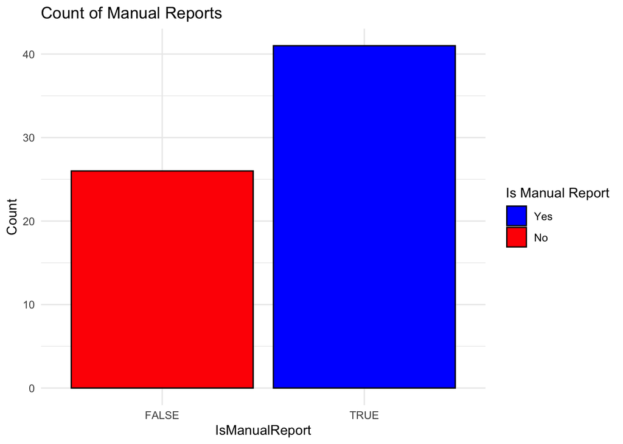

```r
# Create the count plot
ggplot(weightloginfo, aes(x = IsManualReport, fill = as.factor(IsManualReport))) +
  geom_bar(color = "black") +
  scale_fill_manual(values = c("blue", "red"), name = "Is Manual Report",
                    breaks = c("TRUE", "FALSE"), labels = c("Yes", "No")) +
  theme_minimal() +
  labs(title = "Count of Manual Reports", x = "IsManualReport", y = "Count")
```

Average Weight Over Time

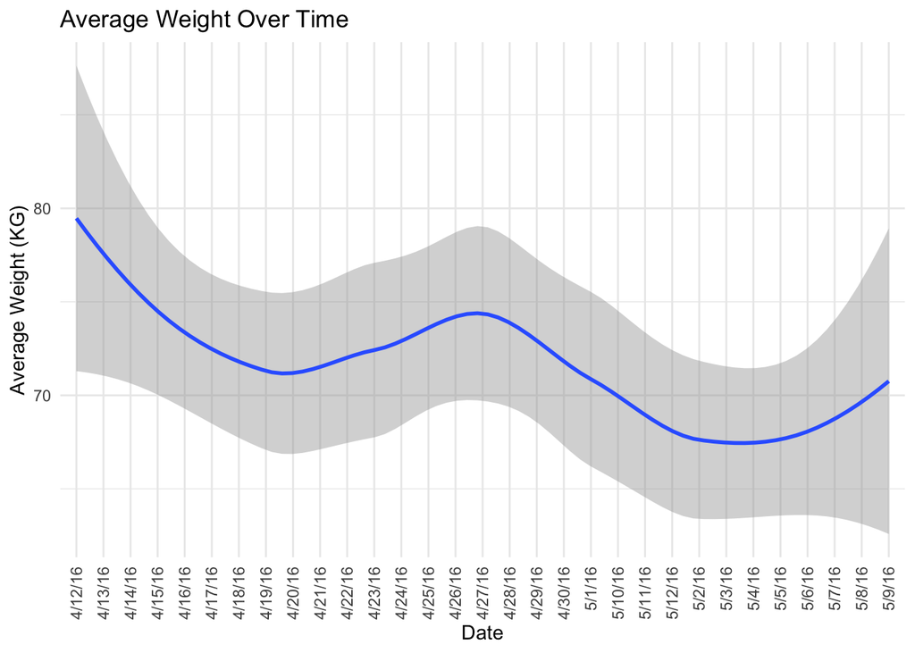

```r
# Weight Loss Over Time
avg_weight_over_time <- weightloginfo %>%
  group_by(Date) %>%
  summarise(AverageWeight = mean(WeightKg, na.rm = TRUE))

ggplot(avg_weight_over_time, aes(x = Date, y = AverageWeight)) +
  geom_smooth(aes(group = 1)) +  # Added group = 1 inside aes() for geom_smooth
  labs(title = "Average Weight Over Time",
       x = "Date",
       y = "Average Weight (KG)") +
  theme_minimal() +
  theme(axis.text.x = element_text(angle = 90, vjust = 0.5, hjust=1))
```

Sleep Duration Over Time

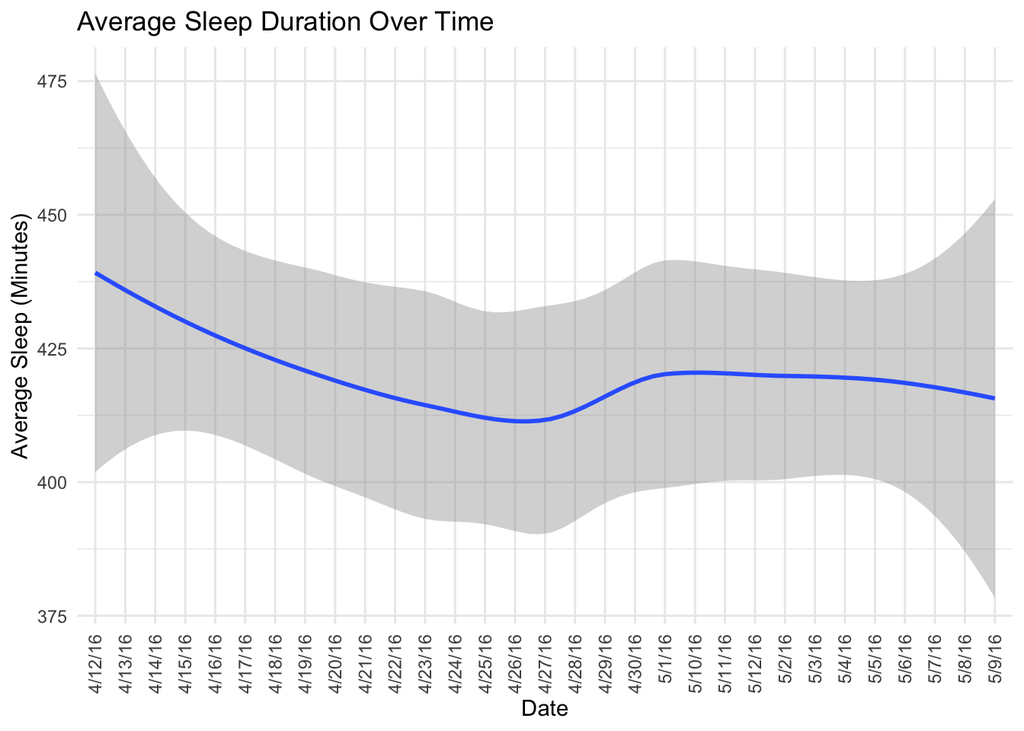

```r
# Calculate average sleep duration over time
avg_sleep_over_time <- sleepday %>%
  group_by(Date) %>%
  summarise(AverageSleep = mean(TotalMinutesAsleep, na.rm = TRUE))

# Plot the data
ggplot(avg_sleep_over_time, aes(x = Date, y = AverageSleep)) +
  geom_smooth(aes(group = 1)) +
  labs(title = "Average Sleep Duration Over Time",
       x = "Date",
       y = "Average Sleep (Minutes)") +
  theme_minimal() +
  theme(axis.text.x = element_text(angle = 90, vjust = 0.5, hjust=1))
```

## Conclusion

I have spot several trends from the charts:

*Activity Level Patterns*: The majority of our users tend to prefer light and sedentary activities over heavily active ones. This might reflect the lifestyle or preference of our current user base. Recognizing this pattern, the company could develop features and programs that cater more towards light exercises and activities that can be performed in a sedentary position, which could help in attracting more users who prefer or are limited to these kinds of activities.

*Manual Logging Behavior*: The analysis also showed that users are actively engaged in logging their activities. This level of engagement is a positive sign, indicating that users are finding value in tracking their fitness activities using our platform.

*Sleep Duration Over Time*: The sleep duration exhibits fluctuations over time, with both periods of decrease and increase. This suggests potential external factors affecting sleep patterns or user adjustments to our app/device.

#### In terms of attracting new users and retaining existing ones, our data suggests the following strategies:

1. Create beginner-friendly content and features.
2. Enhance manual input features for better user engagement.
3. Highlight the potential benefits to weight loss in marketing materials.
4. By investing in understanding and enhancing our sleep features, we can attract more users seeking effective solutions for better sleep. This will drive growth in our subscriber base and establish Bellabeat as a leading brand promoting overall well-being.